# 5 ReprEx tips for getting code help

2022-01-26

## What is ReprEx?

ReprEx means **Reproducible Example**

When asking for help, often online, it helps to provide enough information to EXACTLY REPRODUCE any error you might be getting

Also, take care to provide complete information

- **description of what you are trying to do**
- **minimal data example**
- **code you have already tried** using minimal data

## Is this ReprEx?

Q: Hello I’m adding legends to my boxplots but I found that if I clear the global environment this line

legend(x = 0.5, y = 28, legend = c(‘Year 17’, ‘Year 18’), fill = c(3, 5)))

stops working, it adds the legend correctly if I run the other lines and generate the graph beforehand but if I run the lot together I get the error message

Error in strwidth(legend, units = “user”, cex = cex, font = text.font) : plot.new has not been called yet

It would seem untidy to me to leave the script for the legend separate. Is there a way to get it to run with the rest of the code for that graph please?

## Answer to a non-Reprex:

A: I would need a bit more code about what you are trying to answer, and your output.

I do not understand what scenario would make you clear your global environment between making a plot and drawing a legend on your plot?

e.g. something like this reproducible example works fine:

## Answer to a non-Reprex:

```r
var <- c(1,2,3,4)
factor <- c('a','a','b','b')
data <- data.frame(var, factor)

boxplot(var~factor, data=data,
        col=c('red','blue'))

legend(x=1, y = 3.5, legend = c('a', 'b'),
       col=c('red','blue'), pch=15)
```

## Answer to a non-Reprex:

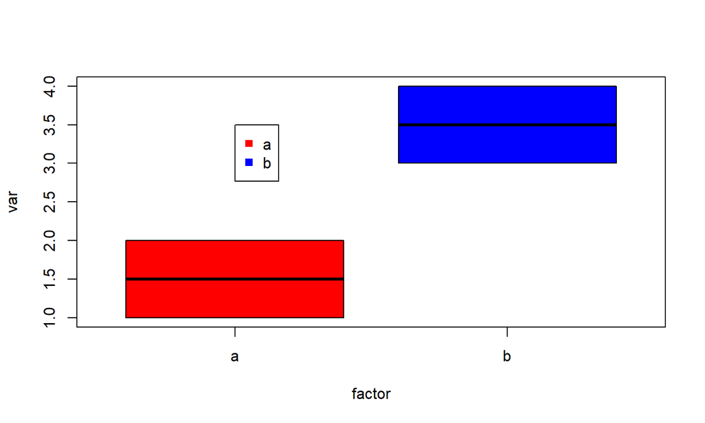

## A good ReprEx has 5 features:

- context
- what do you want to do?
- what have you tried (code, not screenshot)?
- minimal data (probably also code)
- error message or wrong outcome

## Example: Compare means of just 2 of 3 flower spp

```r
data(iris)
head(iris)
```

```
##   Sepal.Length Sepal.Width Petal.Length Petal.Width Species
## 1          5.1         3.5          1.4         0.2  setosa
## 2          4.9         3.0          1.4         0.2  setosa
## 3          4.7         3.2          1.3         0.2  setosa
## 4          4.6         3.1          1.5         0.2  setosa
## 5          5.0         3.6          1.4         0.2  setosa
## 6          5.4         3.9          1.7         0.4  setosa
```

## Example: Compare means of just 2 of 3 flower spp

```r
my_iris <- iris[which(iris$Species != 'virginica')]

Error in `[.data.frame`(iris, which(iris$Species != "virginica")) :
  undefined columns selected
```

## Go through the steps

- context
- what do you want to do?
- what have you tried (code, not screenshot)?
- minimal data (probably also code)
- error message or wrong outcome

## references

[Hadley Wickham on ReprEx](https://gist.github.com/hadley/270442#file-reproducible-md)

[Stack Overflow speaks](https://stackoverflow.com/questions/5963269/how-to-make-a-great-r-reproducible-example)